# AI implementation at work: worker preferences for task changes

employee listening human-ai interaction ai at work

How a choice experiment with 423 quality control operators can inform employee listening and AI-driven job redesign.

Luděk Stehlík https://www.linkedin.com/in/ludekstehlik/  
2026-11-18

What if an employee survey asked you to pick between two versions of your own job?

Lara Fleck and colleagues did something along those lines with 423 quality control operators at an automotive supplier. The operators saw pairs of hypothetical jobs and picked the one they thought would be better for their well-being. The options varied in what they’d do on a shift, when they could take breaks, what training they’d get, how much say they’d have over their tasks, and what they’d earn.

The choices were based on an actual AI rollout. In the first stage, a pop-up asked operators to take another look when the system disagreed with them. The operator still made the call. In the planned second stage, the system would clear the easy cases, leaving operators with fewer, harder ones.

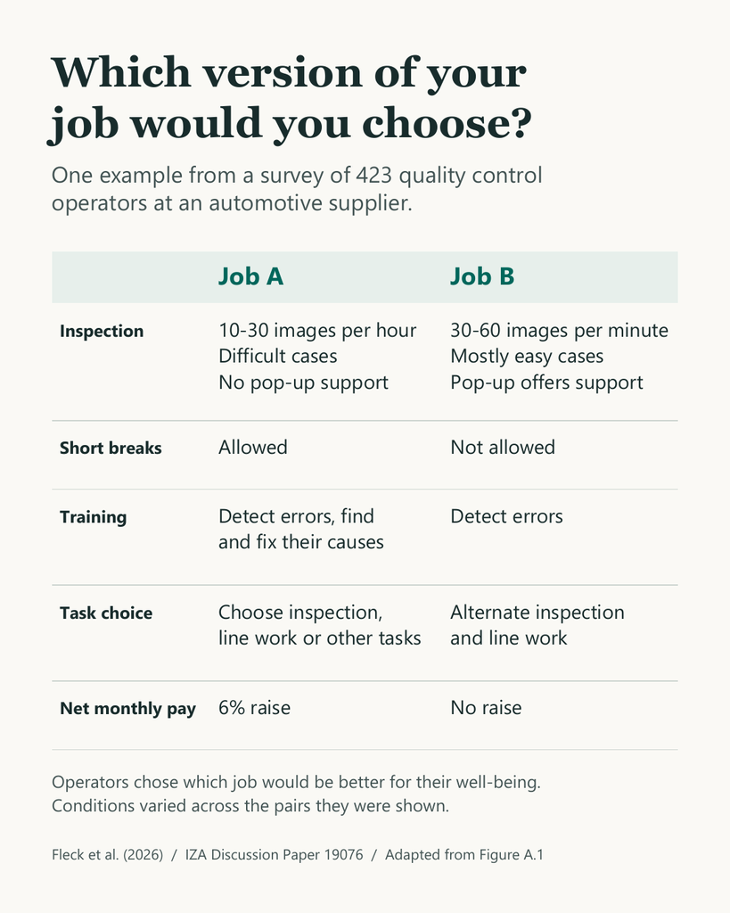

An example pair of hypothetical jobs from the survey. Job A involves fewer, difficult inspections without pop-up support, flexible short breaks, more training, task choice, and a 6% raise. Job B involves more, mostly easy inspections with pop-up support, no flexible short breaks, basic training, fixed task rotation, and no raise. Operators chose the job they thought would be better for their well-being.

Workers preferred the version where they got a second opinion. The 6% raise in the example above was part of one hypothetical job offer. The chart below summarizes choices across the experiment. From those choices, the researchers estimated that workers valued AI-assisted inspection about as much as a 2.8% raise in the old job without AI.

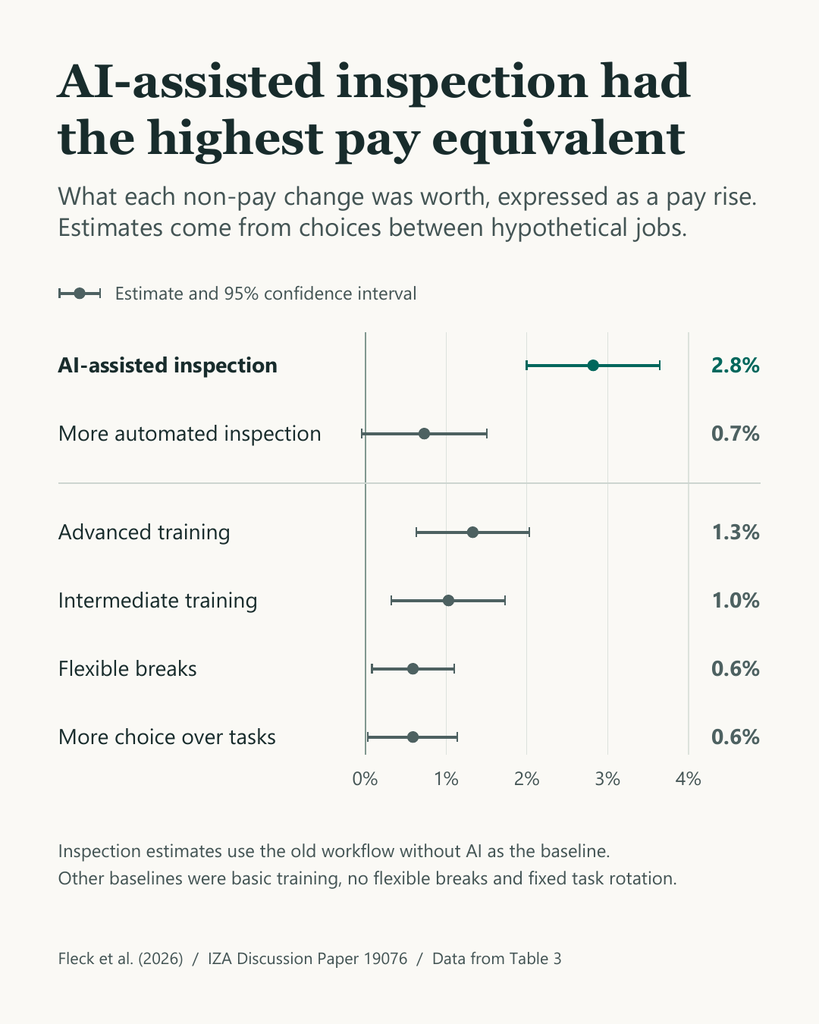

Estimated pay equivalents of job changes, with 95% confidence intervals: AI-assisted inspection, 2.8%; more automated inspection, 0.7%; advanced training, 1.3%; intermediate training, 1.0%; flexible breaks, 0.6%; and more choice over tasks, 0.6%. Inspection estimates use the old workflow without AI as the baseline. Other baselines were basic training, no flexible breaks, and fixed task rotation.

What I like about this as a form of employee listening is how specific you can get. Say you’re about to automate the routine checks. Would people be more interested in the redesigned job if they got more practice on the difficult cases? How much would it matter if they could decide when to switch to another task?

I’d work out a few realistic options with the people doing the job, then use their choices to help decide what to try on the floor.

Have you used a choice experiment in employee listening? What did you ask people to choose between?

Here’s the [IZA working paper](https://www.iza.org/publications/dp/19076) and an [example of what workers saw in the survey](https://docs.iza.org/dp19076.pdf#page=42).

P.S. I focused on the survey design here, but it struck me that the operators who found the AI assistant especially helpful were less keen on the more automated job. A good reminder that when you roll out a change in stages, it’s worth asking people how they’d feel about the next step, even if they’re happy with how things are going so far.

Comment on this article Share:

Enjoy this blog? Get notified of new posts via email: